# Peer-graded Assignment: Prediction Assignment Writeup

## Prediction model

Since we want to predict the class (A, B, C, D, E) to which an observation belongs, this is a classification problem with multiple classes. Therefore, there are several models we can use here. We have chosen the following:

1. Tree Classification.
2. Bagging.
3. Random forest model.

The first model we’re goning to fit is a simple Tree Classification:

```r
tree <- train(factor(classe)~ ., method= "rpart", data = train,
              metric = "Accuracy",
                              preProcess=c("center", "scale"),
                              trControl=trainControl(method = "cv"
                                                       , number = 4
                                                       , p= 0.60
                                                       , allowParallel = TRUE))
tree
```

```
## CART
##
## 12757 samples
##    51 predictor
##     5 classes: 'A', 'B', 'C', 'D', 'E'
##
## Pre-processing: centered (51), scaled (51)
## Resampling: Cross-Validated (4 fold)
## Summary of sample sizes: 9569, 9567, 9568, 9567
## Resampling results across tuning parameters:
##
##   cp          Accuracy   Kappa
##   0.02979189  0.5277950  0.39310109
##   0.03493976  0.5224659  0.38589808
##   0.06336254  0.3271828  0.07161085
##
## Accuracy was used to select the optimal model using the largest value.
## The final value used for the model was cp = 0.02979189.
```

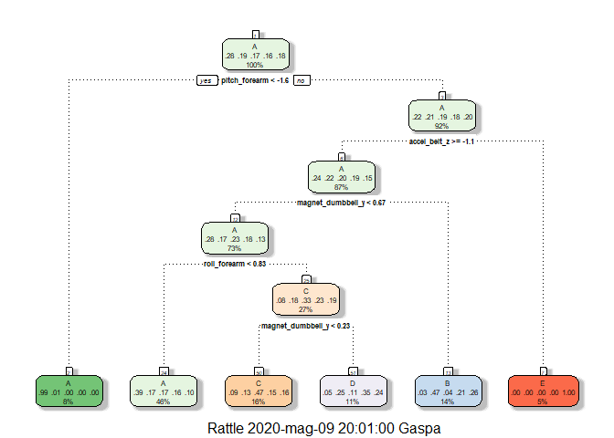

```r
fancyRpartPlot(tree$finalModel)
```

The next models we’re going to fit are the “bagging” and the random forest, which, according to my previsons will be way much better models in evaluate our model.

```r
baggi <- train(factor(classe)~ ., method= "treebag", data = train,
              metric = "Accuracy",
                              preProcess=c("center", "scale"),
                              trControl=trainControl(method = "cv"
                                                       , number = 4
                                                       , p= 0.60
                                                       , allowParallel = TRUE))
baggi
```

```
## Bagged CART
##
## 12757 samples
##    51 predictor
##     5 classes: 'A', 'B', 'C', 'D', 'E'
##
## Pre-processing: centered (51), scaled (51)
## Resampling: Cross-Validated (4 fold)
## Summary of sample sizes: 9568, 9568, 9568, 9567
## Resampling results:
##
##   Accuracy   Kappa
##   0.9810304  0.976003
```

```r
bag_pred <- predict(baggi, test)
confusionMatrix(bag_pred,factor(test$classe))
```

```
## Confusion Matrix and Statistics
##
##           Reference
## Prediction    A    B    C    D    E
##          A 1947   13    0    2    2
##          B    6 1298   12    0    1
##          C    0   15 1178    5    2
##          D    0    1    7 1115    3
##          E    0    1    0    3 1254
##
## Overall Statistics
##
##                Accuracy : 0.9894
##                  95% CI : (0.9866, 0.9917)
##     No Information Rate : 0.2845
##     P-Value [Acc > NIR] : < 2.2e-16
##
##                   Kappa : 0.9865
##
##  Mcnemar's Test P-Value : NA
##
## Statistics by Class:
##
##                      Class: A Class: B Class: C Class: D Class: E
## Sensitivity            0.9969   0.9774   0.9841   0.9911   0.9937
## Specificity            0.9965   0.9966   0.9961   0.9981   0.9993
## Pos Pred Value         0.9913   0.9856   0.9817   0.9902   0.9968
## Neg Pred Value         0.9988   0.9946   0.9966   0.9983   0.9986
## Prevalence             0.2845   0.1934   0.1744   0.1639   0.1838
## Detection Rate         0.2836   0.1891   0.1716   0.1624   0.1827
## Detection Prevalence   0.2861   0.1918   0.1748   0.1640   0.1832
## Balanced Accuracy      0.9967   0.9870   0.9901   0.9946   0.9965
```

```r
Random_Forest <- randomForest(factor(classe) ~ .,
                              data = train,
                              ntree=100
                              , metric = "Accuracy"
                              , preProcess=c("center", "scale")
                              , trControl=trainControl(method = "cv"
                                                       , number = 4
                                                       , p= 0.60
                                                       , allowParallel = TRUE))
```

Both the models show much higher degrees of accuracy in the cross validation tests, both close to $100\%$.

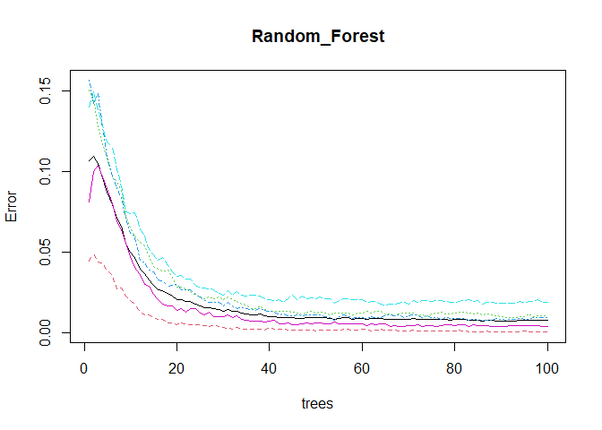

```r
plot(Random_Forest)
```

```r
rf_pred <- predict(Random_Forest, test)
confusionMatrix(rf_pred,factor(test$classe))
```

```
## Confusion Matrix and Statistics
##
##           Reference
## Prediction    A    B    C    D    E
##          A 1952    2    0    0    0
##          B    1 1321    6    0    0
##          C    0    5 1189   10    0
##          D    0    0    2 1114    0
##          E    0    0    0    1 1262
##
## Overall Statistics
##
##                Accuracy : 0.9961
##                  95% CI : (0.9943, 0.9974)
##     No Information Rate : 0.2845
##     P-Value [Acc > NIR] : < 2.2e-16
##
##                   Kappa : 0.995
##
##  Mcnemar's Test P-Value : NA
##
## Statistics by Class:
##
##                      Class: A Class: B Class: C Class: D Class: E
## Sensitivity            0.9995   0.9947   0.9933   0.9902   1.0000
## Specificity            0.9996   0.9987   0.9974   0.9997   0.9998
## Pos Pred Value         0.9990   0.9947   0.9875   0.9982   0.9992
## Neg Pred Value         0.9998   0.9987   0.9986   0.9981   1.0000
## Prevalence             0.2845   0.1934   0.1744   0.1639   0.1838
## Detection Rate         0.2843   0.1924   0.1732   0.1623   0.1838
## Detection Prevalence   0.2846   0.1934   0.1754   0.1626   0.1840
## Balanced Accuracy      0.9995   0.9967   0.9953   0.9949   0.9999
```